# CS 422

Julen Ferro Bañales. Master’s in CDS&OR, Illinois Institute of Technology

```r
#set up of the program, importing required modules
getwd()
```

```
[1] "C:/Users/ferro/Desktop/Disco Duro (17-08-2022) PRE-CHICAGO/DRIVE/University ( 28-11-2020 )/Master/Chicago IIT/Julen Subjects CHICAGO IIT/CS 422 Data Mining/Assignments/HW_4"
```

```r
library(rpart)
library(rpart.plot)
library(caret)
library(ROCR)
library(dplyr)
```

### Part 2.1

### Part 1.A

```r
#The hard way of cleaning data using which

test.df <- read.csv('adult-test.csv', sep = ",", header = TRUE)
train.df <- read.csv('adult-train.csv', sep = ",", header = TRUE)

logic_1 <- c(test.df$age == "?", test.df$workclass == "?", test.df$fnlwgt == "?",
             test.df$education == "?", test.df$education_num == "?",                            test.df$marital_status == "?", test.df$occupation == "?",
             test.df$relationship == "?", test.df$race == "?", test.df$sex == "?",
             test.df$capital_gain == "?", test.df$capital_loss == "?",
             test.df$hours_per_week == "?", test.df$native_country == "?")


outliers <- sum(test.df == "?")
if ( outliers == 0){
  print("The data is already cleaned up")
} else{
  array_1 = which(test.df$native_country == "?" |
                    test.df$occupation == "?" )
  array_2 = which(train.df$native_country == "?" |
                    train.df$occupation == "?")
}

test_c.df <- test.df[-c(array_1), ]
train_c.df <- train.df[-c(array_2), ]
```

```r
#The easy way for cleaning data using for loop

outliers <- sum(test.df == "?")
if ( outliers == 0){
  print("The data is already cleaned up")
} else{
  for (k in 1:ncol(test.df)) {
    test.df = filter(test.df, test.df[, c(k)] != '?')
  }
  for (k in 1:ncol(train.df)) {
    train.df = filter(train.df, train.df[, c(k)] != '?')
  }
}

summary(train_c.df)
```

[output not shown]

```r
summary(test_c.df)
```

[output not shown]

### Part 1-B.

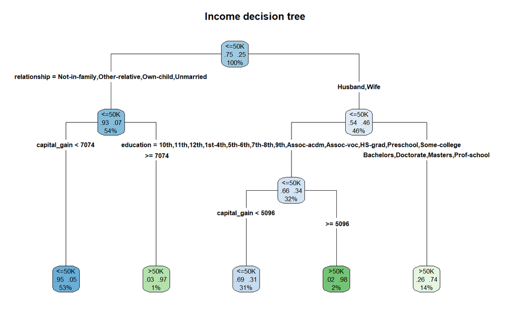

```r
set.seed(1122)

mytree <- rpart(income ~
             age + workclass + fnlwgt +
             education + education_num +
             marital_status + occupation +
             relationship + race + sex +
             capital_gain + capital_loss +
             hours_per_week + native_country,
             train_c.df, method = "class")

rpart.plot(mytree, extra=104, fallen.leaves=T, type=4, main="Income decision tree")
```

```r
NA
```

1. By taking a look at the plotted decision tree, it can be seen that the three most important predictors in the model are: relationship, capital_gain and education.
2. The first prediction is done based on the ‘relationship’ predictor.

The most likely predicted class will be <=50K class. It can be seen that in the 25% of the cases we will get a > 50K classification (from now on, a YES classification).